# Course Project

Natalia Balagaeva

## Introduction

Using devices such as Jawbone Up, Nike FuelBand, and Fitbit it is now possible to collect a large amount of data about personal activity relatively inexpensively. These type of devices are part of the quantified self movement – a group of enthusiasts who take measurements about themselves regularly to improve their health, to find patterns in their behavior, or because they are tech geeks. One thing that people regularly do is quantify how much of a particular activity they do, but they rarely quantify how well they do it. In this project, your goal will be to use data from accelerometers on the belt, forearm, arm, and dumbell of 6 participants. They were asked to perform barbell lifts correctly and incorrectly in 5 different ways. More information is available from the website here: http://groupware.les.inf.puc-rio.br/har (see the section on the Weight Lifting Exercise Dataset).

## Data source

Data Sources The training data for this project are available here: https://d396qusza40orc.cloudfront.net/predmachlearn/pml-training.csv

The test data are available here: https://d396qusza40orc.cloudfront.net/predmachlearn/pml-testing.csv

The data for this project comes from this original source: http://groupware.les.inf.puc-rio.br/har.

*If you use the document you create for this class for any purpose please cite them as they have been very generous in allowing their data to be used for this kind of assignment.*

## Processing the Data

### Import the data from the URLs

```r
train <- "https://d396qusza40orc.cloudfront.net/predmachlearn/pml-training.csv"
test  <- "https://d396qusza40orc.cloudfront.net/predmachlearn/pml-testing.csv"
traincsv <- download.file(train, destfile = ".data")
testcsv  <- download.file(test, destfile = ".data")
```

### Load data locally

```r
training <- read.csv("pml-training.csv", na.strings = c("NA", ""))
testing <- read.csv("pml-testing.csv", na.strings = c("NA", ""))
dim(training)
```

```
## [1] 19622   160
```

```r
dim(testing)
```

```
## [1]  20 160
```

The training dataset has 19622 observations and 160 variables, and the testing data set contains 20 observations and the same variables as the training set. We are trying to predict the outcome of the variable classe in the training set.

## Cleaning data

First we delete all colums of the training set that contain any missing values.

```r
training <- training[, colSums(is.na(training)) == 0]
testing <- testing[, colSums(is.na(testing)) == 0]
```

Now we delete all columns that don’t correlate much to the accelerometer measurements.

```r
trainData <- training[, -c(1:7)]
testData <- testing[, -c(1:7)]
dim(trainData)
```

```
## [1] 19622    53
```

```r
dim(testData)
```

```
## [1] 20 53
```

The cleaned data sets trainData and testData both have 53 columns

## Split data into training and testing

```r
library(caret)
set.seed(1364)
inTrain <- createDataPartition(trainData$classe, p=0.70, list=FALSE)
training1 <- trainData[inTrain, ]
testing1<- trainData[-inTrain, ]
```

## Data Model

Fit a predictive model using classification trees and Random Forest algorithms - Classification trees

```r
contr <- trainControl(method = "cv", number = 5)
fitrp <- train(classe ~ ., data = training1, method = "rpart",
                   trControl = contr)
print(fitrp, digits = 4)
```

```
## CART
##
## 13737 samples
##    52 predictor
##     5 classes: 'A', 'B', 'C', 'D', 'E'
##
## No pre-processing
## Resampling: Cross-Validated (5 fold)
## Summary of sample sizes: 10990, 10988, 10989, 10991, 10990
## Resampling results across tuning parameters:
##
##   cp       Accuracy  Kappa
##   0.02716  0.5506    0.42638
##   0.04236  0.4444    0.26094
##   0.11454  0.3155    0.04749
##
## Accuracy was used to select the optimal model using  the largest value.
## The final value used for the model was cp = 0.02716.
```

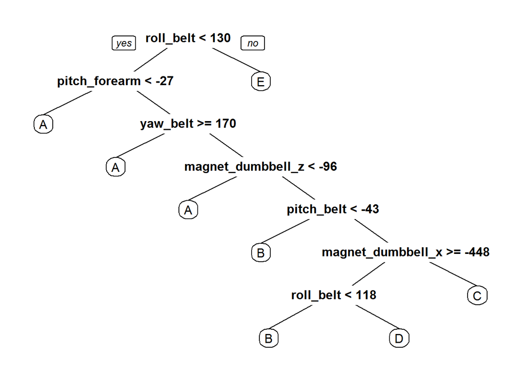

```r
library(rpart.plot)
rpart.plot(fitrp$finalModel)
```

Predict outcomes using testing set and show accuracy of prediction result

[output not shown]

```r
accuracy_rp <- conf_rp$overall[1]
accuracy_rp
```

```
##  Accuracy
## 0.5580289
```

Accuracy is 0.5580289 and it mean that classification tree doesn’t predict well Class. And it’s not the best we can do.

- Random forest

[output not shown]

Predict outcomes using testing set and show accuracy of prediction result

```r
accuracy_rf <- conf_rf$overall[1]
accuracy_rf
```

```
##  Accuracy
## 0.9932031
```

```r
Eerror<-1 - as.numeric(conf_rf$overall[1])
Eerror
```

```
## [1] 0.006796941
```

For this dataset, random forest method is way better than classification tree method. The accuracy rate is 0.9932031, and so the out-of-sample error rate is 0.0067969.

## Predict on the testing dataset

```r
predict(model, testData)
```

```
##  [1] B A B A A E D B A A B C B A E E A B B B
## Levels: A B C D E
```